# Session 2: Parameters Estimate

David Munoz Tord

October 16, 2022

# Setup

### Load libraries

```r
library(ggplot2)
```

# Simulation

The goal of this code is to create a small simulation study to:

1. illustrate central limit theorem
2. show that 95% of generated samples should contain the true parameters

### Let’s generate some data

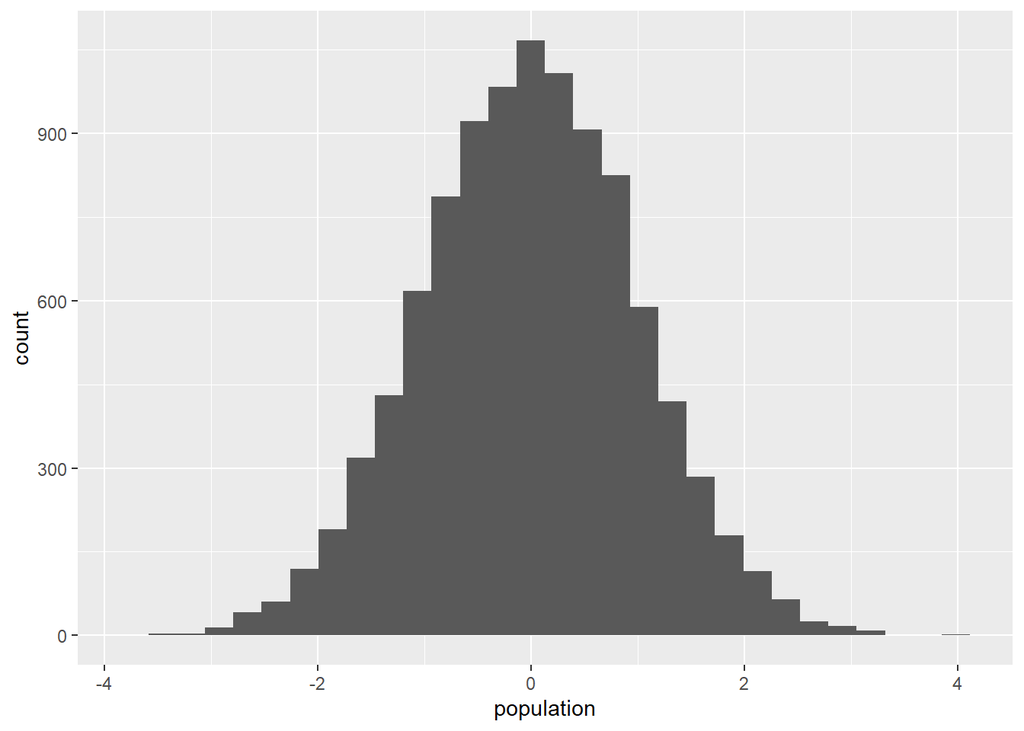

```r
#random generation for the normal distribution with mean equal to mean and standard deviation equal to sd.
population <- rnorm(10000, mean=0, sd=1)

ggplot() + geom_histogram(aes(population)) #do a simple histogram
```

### Resample

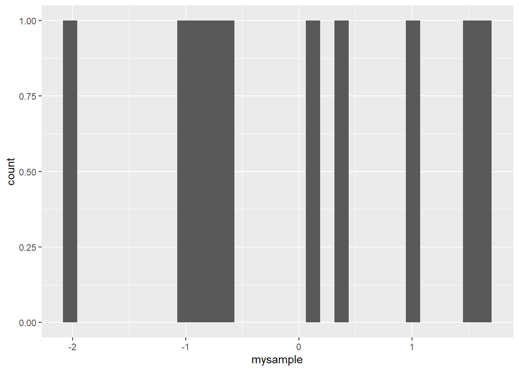

```r
sample_size <- 10 # you can play around with this number

mysample <- sample(population, sample_size) #take a data + a sample size

ggplot() + geom_histogram(aes(mysample)) #do a simple histogram
```

Can you describe the differences ?

### Calculate sample’s statistics

```r
summary(mysample)
```

```
    Min.  1st Qu.   Median     Mean  3rd Qu.     Max.
-1.97458 -0.82362 -0.24841 -0.04619  0.87927  1.68849
```

We now create 100 sample of size `sample_size`, with their statistics:

```r
size = 100

#this creates a dataframe with fix parameters (do not need to understand this code)
#rep() juste repeat a number over the number of time you want

# this is are all random number has placeholder for later
mySampleRes <- data.frame(mean=rep(0,size),
                          sd=rep(1,size),
                          sample = rep(NA,size),
                          se=rep(1/sqrt(10),size),
                          confintLow=rep(0,size),
                          confintHi=rep(0,size))

head(mySampleRes) # all rows are the same for now
```

```
  mean sd sample        se confintLow confintHi
1    0  1     NA 0.3162278          0         0
2    0  1     NA 0.3162278          0         0
3    0  1     NA 0.3162278          0         0
4    0  1     NA 0.3162278          0         0
5    0  1     NA 0.3162278          0         0
6    0  1     NA 0.3162278          0         0
```

the real mean of my original population is 0

```r
#loop through each row

for (i in 1:size){
  mysample <- sample(population, sample_size)#sample from population, same as above
  mySampleRes$sample[i] <- i #assign an incemental index
  mySampleRes$mean[i] <- mean(mysample) #calculate the mean of this random sample
  mySampleRes$sd[i] <- sd(mysample) #calculate the standard deviation of this random sample
  mySampleRes$min[i] <- min(mysample) #calculate the minimum of this random
  mySampleRes$se[i] <- mySampleRes$sd[i]/sqrt(sample_size) #calculate the sampling error of this random sample
  mySampleRes$confintLow[i] <- mySampleRes$mean[i]-1.96*mySampleRes$se[i] #calculate the lower 95% confidence interval of this random sample
  mySampleRes$confintHi[i] <- mySampleRes$mean[i]+1.96*mySampleRes$se[i] #calculate the upper 95% confidence
}

head(mySampleRes)
```

```
          mean        sd sample        se confintLow confintHi       min
1  0.001484251 1.2346710      1 0.3904373 -0.7637728 0.7667413 -2.206631
2 -0.057391263 0.8752810      2 0.2767881 -0.5998960 0.4851135 -1.255706
3  0.123045247 1.2261399      3 0.3877395 -0.6369241 0.8830146 -1.896941
4 -0.011226212 0.5002935      4 0.1582067 -0.3213113 0.2988589 -0.803166
5  0.006520378 1.1112550      5 0.3514097 -0.6822426 0.6952834 -2.572578
6  0.258490825 1.0733192      6 0.3394133 -0.4067593 0.9237410 -1.022345
```

```r
# for reference:
# Confidence level Confidence interval (mean ± sampling error)
# 68% mean ± (1.0) x (SE)
# 95% mean ± (1.96) x (SE)
# 99% mean ± (2.58) x (SE)
# Bonus: Can you describe/explain/visualize why ?
```

```r
mySampleRes$within_confint <- factor(mySampleRes$confintLow < 0 & mySampleRes$confintHi > 0, labels = c("Outside", "Inside")) # create variable to check if we have found and estimate (mean) which its confindence intervals doesn't include 0


table(mySampleRes$within_confint)
```

```
Outside  Inside
      8      92
```

Let’s plot it !

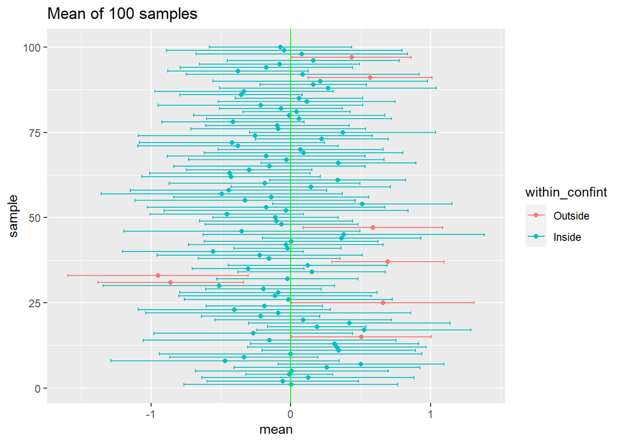

```r
ggplot(mySampleRes,
       aes(sample,mean,color = within_confint))+
  geom_point()+
  geom_errorbar(aes(ymin = confintLow,ymax = confintHi))+
  geom_hline(yintercept = 0,color = "green")+
  coord_flip()+
  labs(title = "Mean of 100 samples")
```

Red estimates are different than zero with 95% confidence

### Distribution of the means

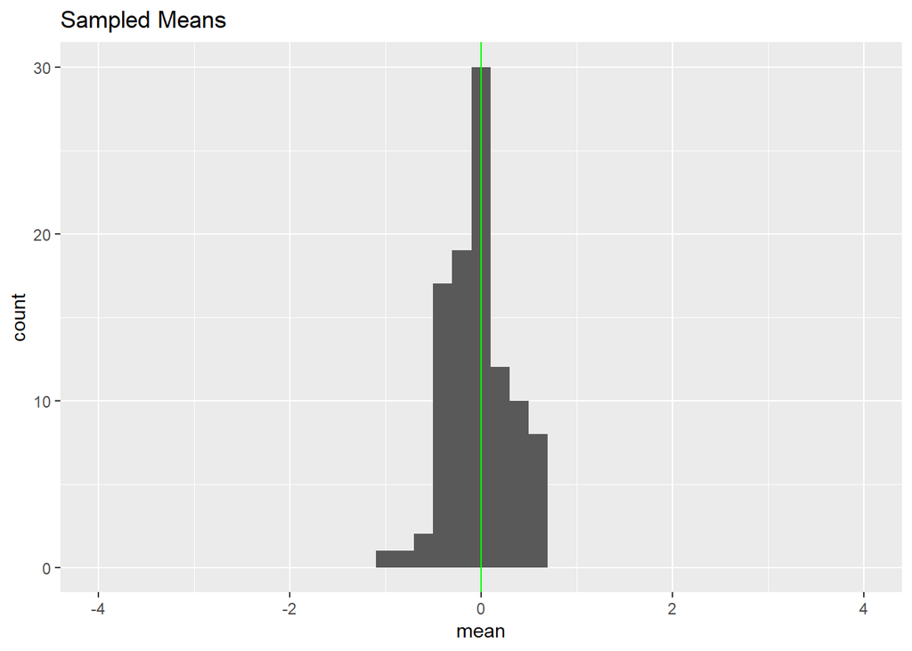

```r
p_sample <- ggplot()+
  geom_histogram(data = mySampleRes,
                 aes(x=mean),binwidth = .2) +
  xlim(round(min(population)),round(max(population))) +
  geom_vline(xintercept = 0,color = "green") +
  labs(title = "Sampled Means")

p_sample
```

Distribution of the means depends on the sample size.

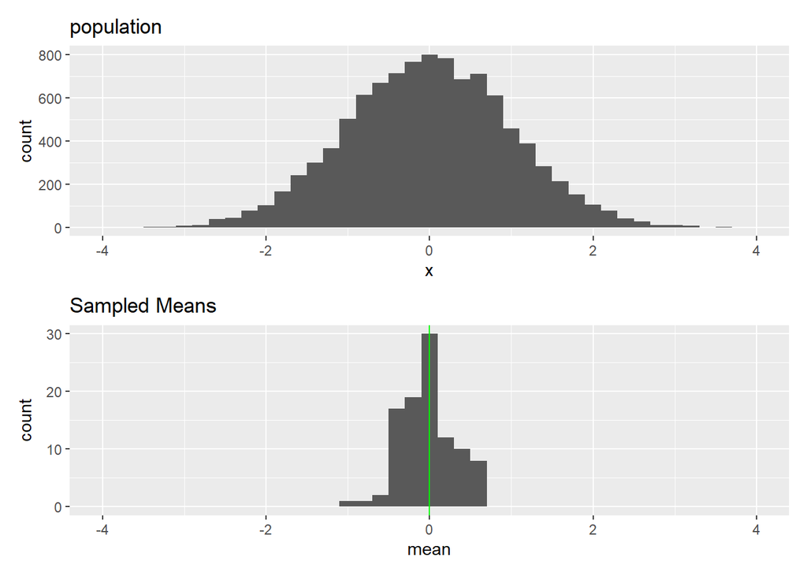

```r
library(patchwork)
#install.packages('patchwork')
p_population <- ggplot()+
                geom_histogram(data = data.frame(x = population),
                               aes(x=x),binwidth = .2)+
                  xlim(round(min(population)),round(max(population)))+
                  labs(title = "population")


p_population / p_sample
```

# Same with the minimum

What we did with the mea cannot work with the min, or max, or sd. Let’s see. The true min is:

```r
true_min <- min(population)
```

I create a confidence interval of teh sampled min:

```r
mySampleRes$confintLow_min <- mySampleRes$min-1.96*mySampleRes$se #calculate the lower 95% confidence interval of this random sample
mySampleRes$confintHi_min <- mySampleRes$min+1.96*mySampleRes$se #calculate the upper 95% confidence interval of this random sample
```

I create a variable saying if the true value is within my confidence interval:

```r
mySampleRes$within_confint_min <- ifelse(mySampleRes$confintLow_min < true_min & mySampleRes$confintHi_min > true_min,"Outside","Inside") # create variable to check if we have found and estimate (mean) which its confindence intervals doesn't include 0
```

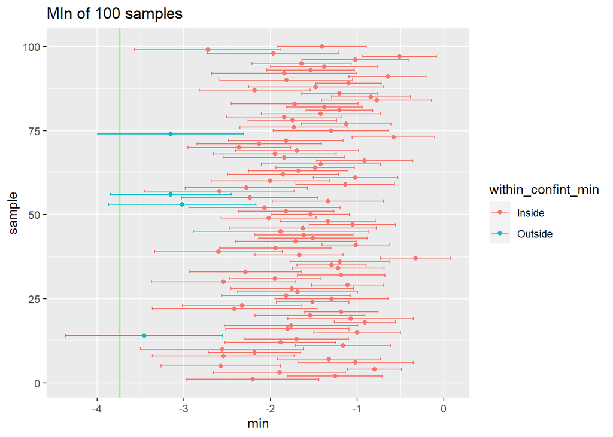

```r
ggplot(mySampleRes,
       aes(sample,min,color = within_confint_min))+
  geom_point()+
  geom_errorbar(aes(ymin = confintLow_min,ymax = confintHi_min))+
  geom_hline(yintercept = true_min,color = "green")+
  coord_flip()+
  labs(title = "MIn of 100 samples")
```

We see most of sampled min are too far fro the true min! The distribution of the minimum is not centered on the true min:

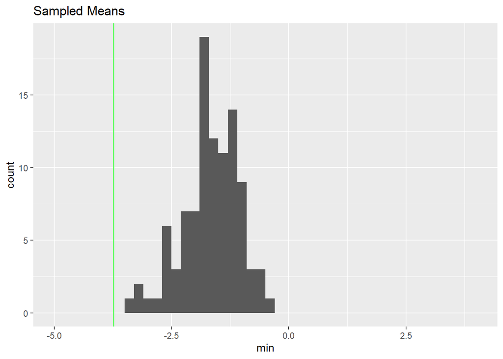

```r
p_sample_min <- ggplot()+
  geom_histogram(data = mySampleRes,
                 aes(x=min),
                 binwidth = .2) +
  xlim(round(min(population))-1,round(max(population))) +
  geom_vline(xintercept = true_min,color = "green") +
  labs(title = "Sampled Means")

p_sample_min
```